# Vizualizing Sales Through 2016

Allocate Analytics

July 25, 2018

##### Headline: This document shows sales each hour each day of 2016. It shows them in 3 ways: dollars, checks/tables, and items ordered. Here are the largest takeaways from these charts:

- The biggest trend is the way sales change across a week, i.e. the way a Friday is different from a Thursday is more important than the difference between February and July.
- Based on dollars, dinners are bigger, but based on the number of checks and on the number of items sold lunch is bigger. To a server, the busy-ness might be measured based on tables per hour (checks). To a cook, busy-ness might be measured by the number of individual items prepared. And to a manager, busy-ness might be measured by $ per hour.
- There are infrequent, large transactions that make most other hours look tiny. I suspect these are catering orders but haven’t found anything that distinguishes them that would allow them to be filtered out.

### Original Calendar Plot from sales - Plot 1

Some large transactions make certain hours throughout the year so large that everything looks flat. This plot may be helpful in identifying when those huge days and hours are, but isn’t helpful in seeing what the regular trends are.

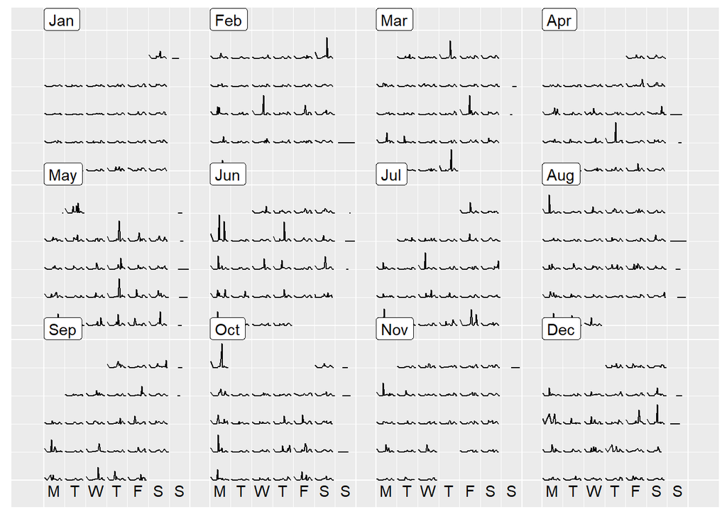

### Plot by $ Without Outliers - Plot 2

Plot 2 is the same as plot 1 except that the largest 1% of checks are removed. Here trends begin to emerge.

- Friday dinner is most often the biggest meal of the week, but there are times when Thursday dinner and Saturday dinner are the largest
- Saturday lunch/brunch lasts significantly longer than other days

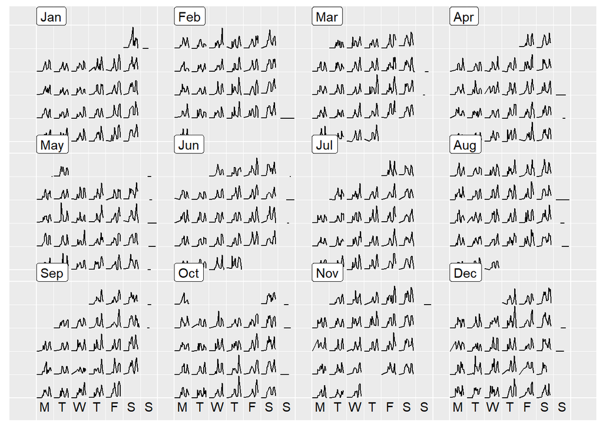

### Plot showing volume based on checks - Plot 3

This plot is based on how many checks were entered each hour regardless of the amount of the check.

- This shows that the vast majority of days have more checks entered during lunch than during dinner

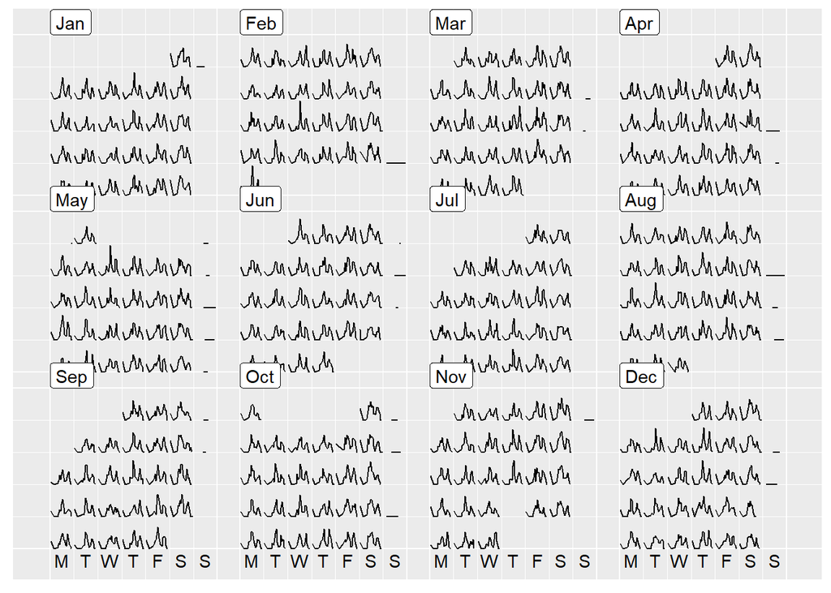

### Plot showing volume based on items sold - Plot 4

This plot shows how many items were ordered by hour, and it largely follows the shape of Plot 3, based on number of checks.

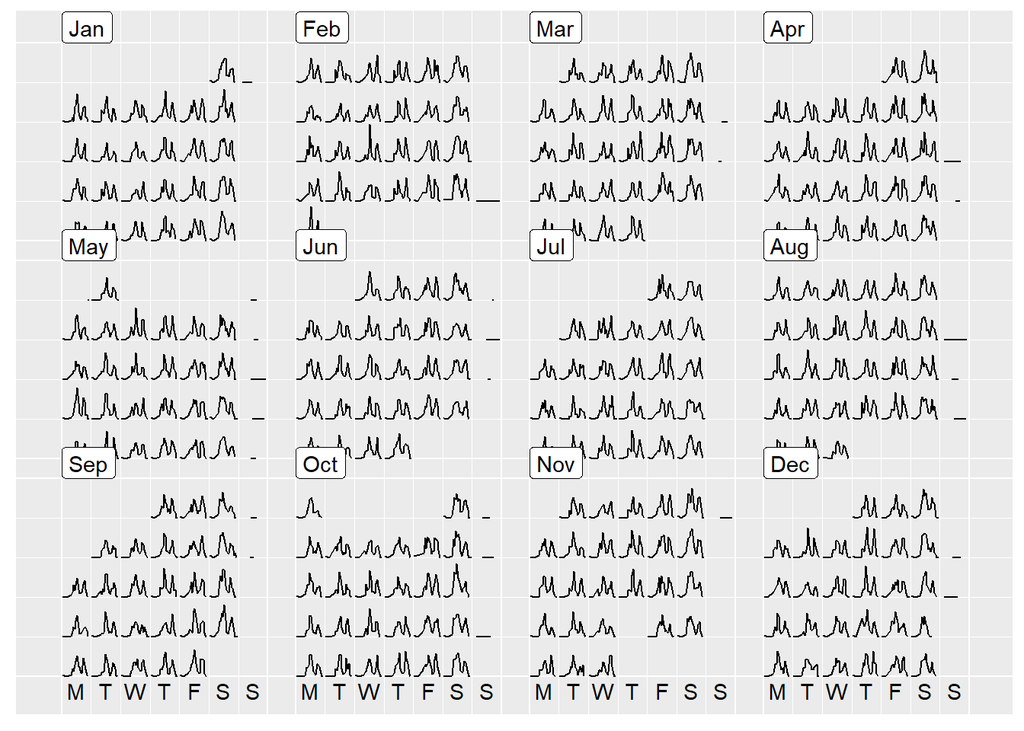